# Module 8: Solutions to Recommended Exercises

TMA4268 Statistical Learning V2025

Sara Martino, Stefanie Muff, Kenneth Aase

Department of Mathematical Sciences, NTNU

March 12, 2025

## Problem 1 – Theoretical

1. *Recursive binary splitting*: We find the best single partitioning of the data such that the reduction of RSS is the greatest. This process is applied sequencially to each of the split parts until a predefined minimum number of leave observation is reached.
2. *Cost complexity pruning* of the large tree from previoius step, in order to obtain a sequence of best trees as a function of a parameter $\alpha$. Each value of $\alpha$ corresponds to a subtree that minimize the following equation (several $\alpha$s for the same tree):

$$\sum_{m=1}^{|T|}\sum_{i:x_i\in R_m}(y_i - \hat y_{R_m})^2 + \alpha |T|,$$

where $|T|$ is the number of terminal nodes.

3. *$K$-fold cross-validation* to choose $\alpha$. For each fold:
- Repeat Steps 1 and 2 on all but the kth folds of the training data.
- Evaluate the mean squared prediction on the data in the left-out kth fold, as a function of $\alpha$.
- Average the results for each value of $\alpha$ and choose $\alpha$ to minimize the average error.
4. Return the subtree from Step 2 that corresponds to the chosen value of $\alpha.$

For a **classification** tree, we replace RSS with Gini index or cross entropy.

$\color{green}{\text{Advantages}}$

- Very easy to explain
- Can be displayed graphically
- Can handle both quantitative and qualitative predictors without the need to create dummy variables

$\color{red}{\text{Disadvantages}}$

- The predictive accuracy is usually not very high. This limitation often leads practitioners to use ensemble methods like Random Forests or Boosting to improve accuracy.
- They are non-robust. That is, a small change in the data can cause a large change in the estimated tree.

*Limitation of decision trees*: Decision trees suffer from high variance. Recall that if we have $B$ $i.i.d$ observations of a random variable $X$ with the same mean and variance $\sigma^2.$ We calculate the mean $\bar{X} = \frac{1}{B} \sum_{b=1}^B X_b,$ and the variance of the mean is $\text{Var}(\bar{X}) = \frac{\sigma^2}{B}.$ That is by averaging we get reduced variance.

*Idea behind bagging*: For decision trees, if we have $B$ training sets, we could estimate $\hat{f}_1({\boldsymbol x}),\hat{f}_2({\boldsymbol x}),\ldots, \hat{f}_B({\boldsymbol x})$ and average them as
$$\hat{f}_{avg}({\boldsymbol x})=\frac{1}{B}\sum_{b=1}^B
\hat{f}_b({\boldsymbol x}) \ .$$
However we do not have many data independent data sets, and we bootstraping to create $B$ datasets. These datasets are however not completely independent and the reduction in variance is therefore not as large as for independent training sets.

*How do random forests improve that idea?*: To make the different trees that are built from each bootstrapped dataset more different, random forests use a random subset of the predictors to split the tree into new branches at each step. This decorrelates the different trees that are built from the $B$ bootstrapped datasets, and consequently reduces variance.

4. An OOB is the set of observations that were not chosen to be in a specific bootstrap sample. From RecEx5-Problem 4c we have that on average $1-0.632 = 0.368$ are included in the OOB sample.

**Variable importance based on node impurity**

- *Regression Trees*: The total amount that the RSS is decreased due to splits of each predictor, averaged over the B trees.
- *Classification Trees*: The importance is the mean decrease (over all B trees) in impurity (often measured by the Gini index) by splits of a predictor. A higher decrease indicates a more significant role of the predictor in partitioning the data into homogeneous groups, thereby enhancing classification accuracy.

**Variable importance based on randomization**

- This measure is based on how much the predictive accuracy (MSE or gini indiex) is decreased when the variable is replaced by a permuted version of it. You find a drawing [here](https://github.com/stefaniemuff/statlearning/blob/master/8Trees/M8_variableImportanceRandomization.pdf).

## Problem 2 – Regression (Book Ex. 8)

```r
library(ISLR)
data("Carseats")
set.seed(4268)
n <- nrow(Carseats)
train <- sample(n, 0.7*nrow(Carseats), replace = FALSE)
Carseats.train <- Carseats[train,]
Carseats.test <- Carseats[-train,]
```

```r
library(tree)
tree.mod <- tree(Sales ~ ., Carseats, subset = train)
summary(tree.mod)
```

```
##
## Regression tree:
## tree(formula = Sales ~ ., data = Carseats, subset = train)
## Variables actually used in tree construction:
## [1] "ShelveLoc"   "Price"       "Age"         "Income"      "CompPrice"
## [6] "Population"  "Advertising" "Education"
## Number of terminal nodes:  18
## Residual mean deviance:  2.609 = 683.6 / 262
## Distribution of residuals:
##     Min.  1st Qu.   Median     Mean  3rd Qu.     Max.
## -3.74000 -1.12400 -0.06522  0.00000  1.06800  4.47200
```

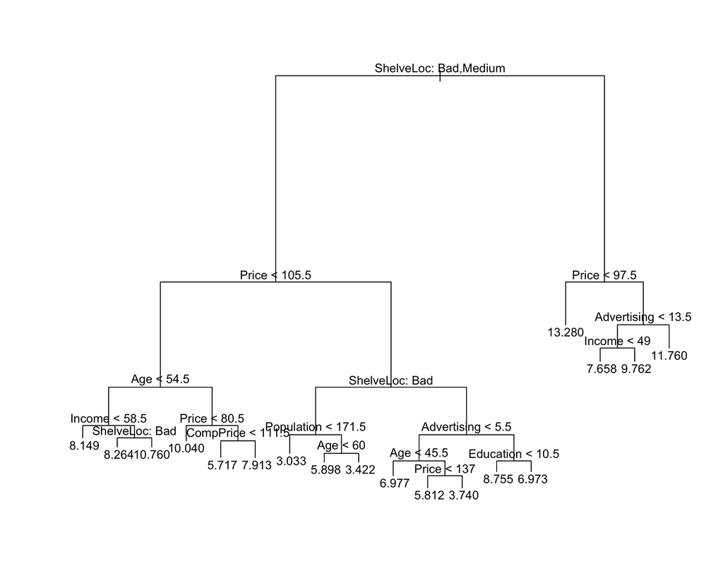

```r
plot(tree.mod)
text(tree.mod, pretty = 0)
```

- Shelf location (‘ShelveLoc’) is should be one of the important predictors, with bad/medium locations correlating with lower sales while good location leads to higher sales in general.
- Age criteria suggests that younger customers tend to contribue higher sales.
- For higher prices, Advertising becomes relevant, indicating that higher marketing efforts result in higher sales.
- etc.

```r
yhat <- predict(tree.mod, newdata = Carseats.test)
mse <- mean((yhat - Carseats.test$Sales)^2)

cat("test MSE:", mse)
```

```
## test MSE: 4.585249
```

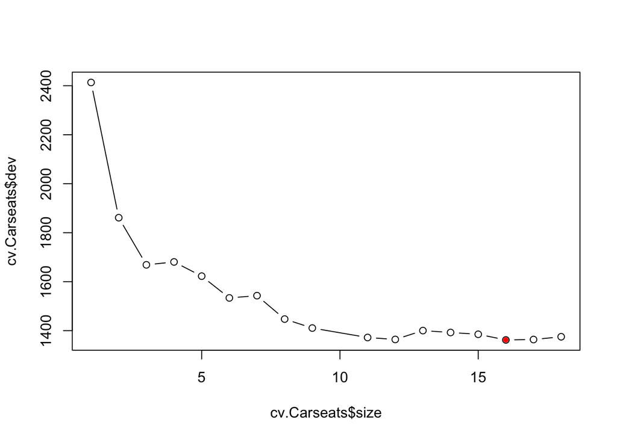

```r
set.seed(4268)
cv.Carseats <- cv.tree(tree.mod)
tree.min <- which.min(cv.Carseats$dev)
best <- cv.Carseats$size[tree.min]
plot(cv.Carseats$size, cv.Carseats$dev, type = "b")
points(cv.Carseats$size[tree.min],
       cv.Carseats$dev[tree.min],
       col = "red",
       pch = 20)
```

We see that trees with sizes 11, 12, 16 and 17 have similar deviance values. We might choose the tree of size 11 as it gives the simpler tree.

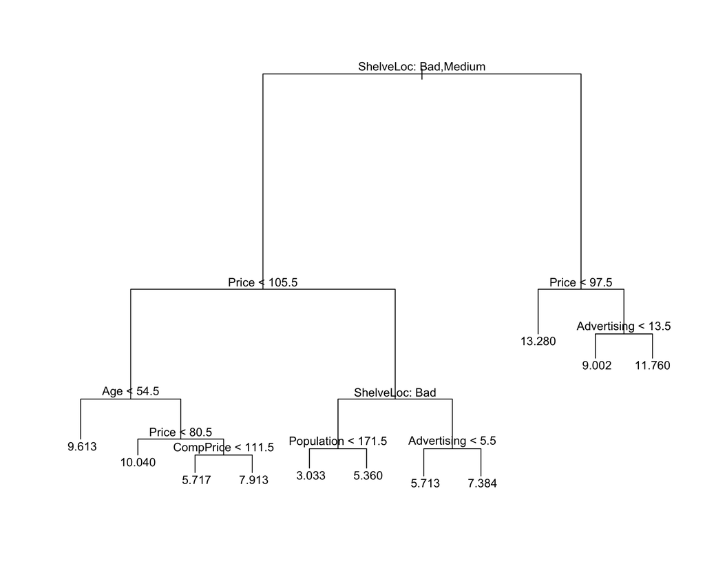

```r
pr.tree <- prune.tree(tree.mod, best = 11)
plot(pr.tree)
text(pr.tree, pretty = 0)
```

```r
yhat <- predict(pr.tree, newdata = Carseats.test)
mse <- mean((yhat - Carseats.test$Sales)^2)
mse
```

```
## [1] 4.378499
```

There is a slight reduction in MSE for the pruned tree with 11 leaves.

```r
library(randomForest)
dim(Carseats)
```

```
## [1] 400  11
```

```r
bag.Carseats <- randomForest(Sales ~ .,
                             Carseats.train,
                             mtry = ncol(Carseats) - 1,
                             ntree = 500,
                             importance = TRUE)
yhat.bag <- predict(bag.Carseats, newdata = Carseats.test)
mse.bag <- mean((yhat.bag - Carseats.test$Sales)^2)
mse.bag
```

```
## [1] 2.122958
```

Bagging decreases the test MSE significantly to 2.12. From the importance plots we might conclude that `Price`and `ShelveLoc` are the most important Variables.

```r
importance(bag.Carseats)
```

```
##               %IncMSE IncNodePurity
## CompPrice   26.803869    218.740455
## Income      10.284817    127.447480
## Advertising 25.795425    196.438893
## Population   6.084270     92.149065
## Price       67.791459    667.696518
## ShelveLoc   75.485534    734.902022
## Age         24.961130    229.491494
## Education    3.423565     64.510742
## Urban       -1.373635      9.423406
## US           3.141449     10.105870
```

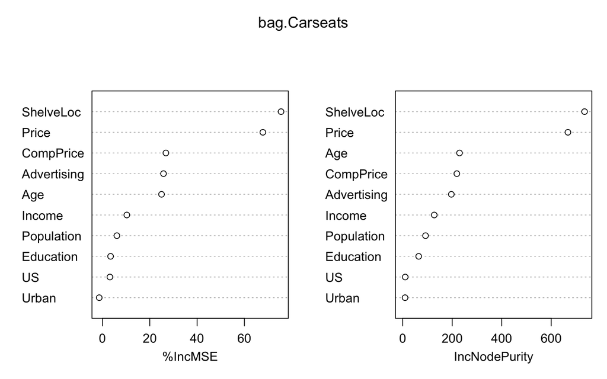

```r
varImpPlot(bag.Carseats)
```

```r
rf.Carseats <- randomForest(Sales ~ .,
                            data = Carseats.train,
                            mtry = 3,
                            ntree = 500,
                            importance = TRUE)
yhat.rf <- predict(rf.Carseats, newdata = Carseats.test)
mse_forest <- mean((yhat.rf - Carseats.test$Sales)^2)
mse_forest
```

```
## [1] 2.25397
```

```r
importance(rf.Carseats)
```

```
##               %IncMSE IncNodePurity
## CompPrice   15.789484     211.79213
## Income       5.415374     174.79625
## Advertising 18.402600     210.47149
## Population   1.076874     148.09993
## Price       45.548596     577.68865
## ShelveLoc   47.810006     549.62278
## Age         15.936114     241.99130
## Education    3.275725     104.89503
## Urban       -1.646580      19.63668
## US           5.427599      36.45647
```

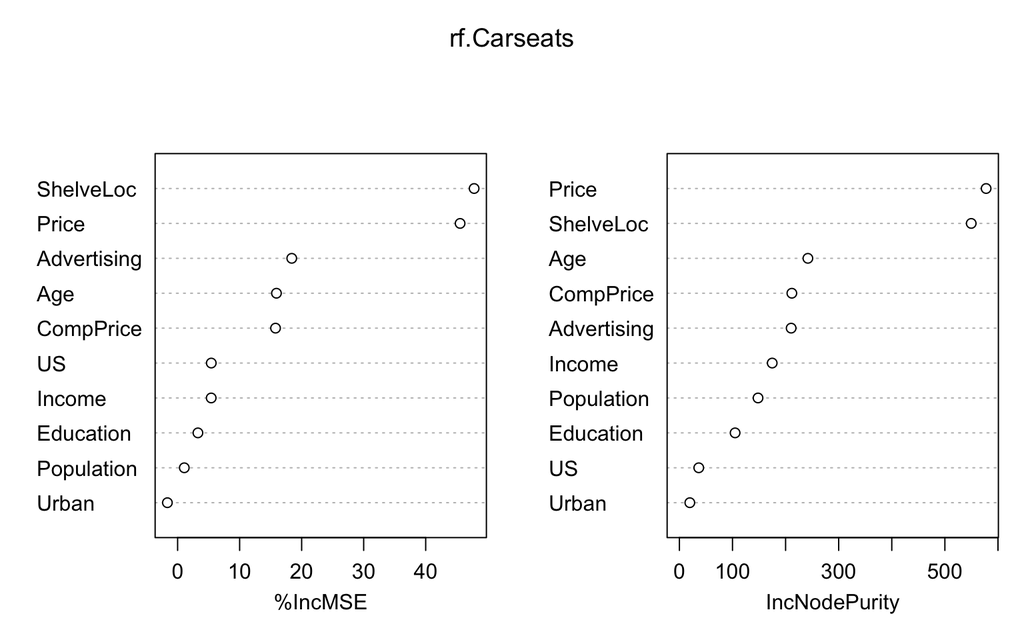

```r
varImpPlot(rf.Carseats)
```

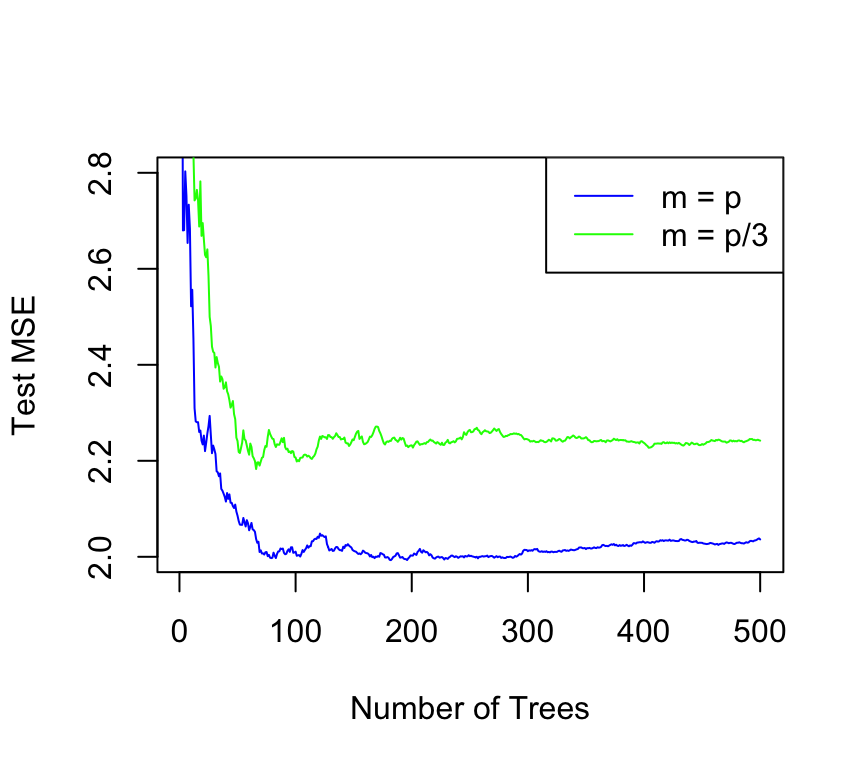

```r
set.seed(123)

train.predictors <- Carseats.train[, -1]
test.predictors <- Carseats.test[, -1]
Y.train <- Carseats.train[, 1]
Y.test <- Carseats.test[, 1]

ntree <- 500
bag.Car <- randomForest(train.predictors,
                        y = Y.train,
                        xtest = test.predictors,
                        ytest = Y.test,
                        mtry = 10,
                        ntree = ntree)
rf.Car <- randomForest(train.predictors,
                       y = Y.train,
                       xtest = test.predictors,
                       ytest = Y.test,
                       mtry = 3,
                       ntree = ntree)
plot(1:ntree,
     bag.Car$test$mse,
     col = "blue",
     type = "l",
     xlab = "Number of Trees",
     ylab = "Test MSE",
     ylim = c(2, 2.8))
lines(1:ntree, rf.Car$test$mse, col = "green")

legend("topright",
       c("m = p", "m = p/3"),
       col = c("blue", "green"),
       cex = 1,
       lty = 1)
```

NB! Typically, RandomForest models outperform Bagging models due to their decorrealtion property stemming from a limited selection of predictors.

## Problem 3 – Classification

```r
library(kernlab)
data(spam)
```

```r
?spam
```

```r
library(ISLR)
set.seed(4268)
n <- nrow(spam)
train <- sample(1:n, 0.7 * n, replace = FALSE)
test <- (1:n)[-train]
spam.train <- spam[train,]
spam.test <- spam[-train,]
```

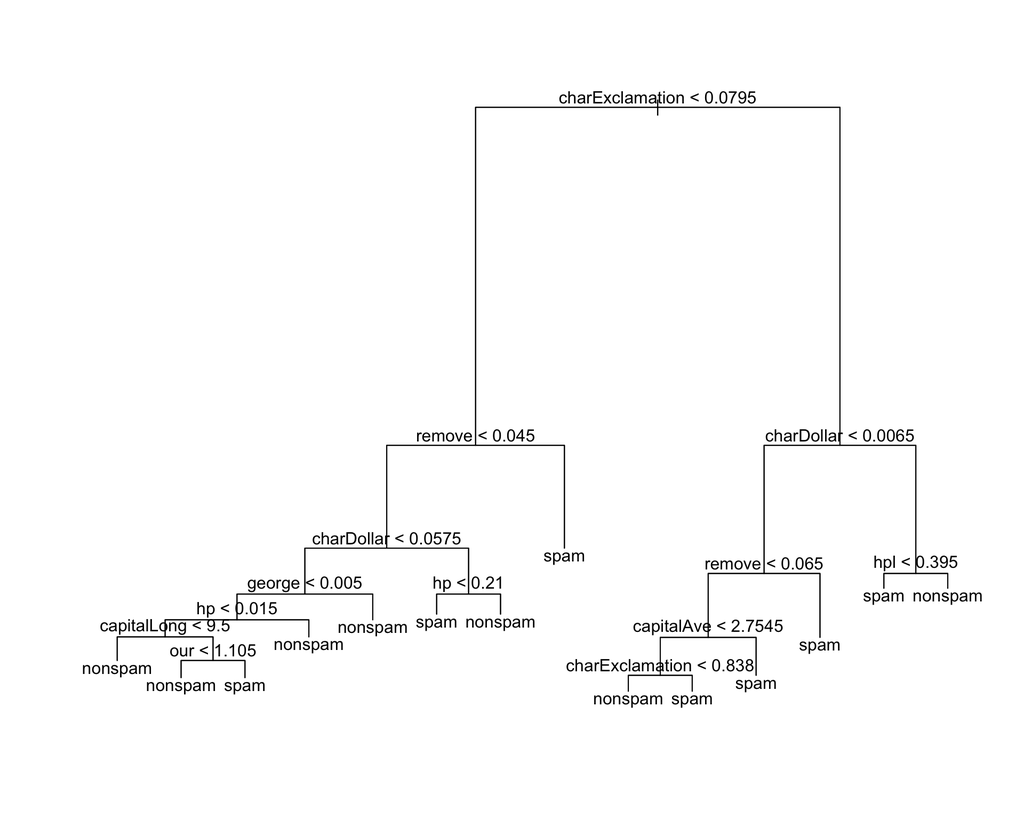

```r
spam.tree <- tree(type~.,spam,subset=train)

plot(spam.tree)
text(spam.tree, pretty = 1)
```

```r
summary(spam.tree)
```

```
##
## Classification tree:
## tree(formula = type ~ ., data = spam, subset = train)
## Variables actually used in tree construction:
## [1] "charExclamation" "remove"          "charDollar"      "george"
## [5] "hp"              "capitalLong"     "our"             "capitalAve"
## [9] "hpl"
## Number of terminal nodes:  14
## Residual mean deviance:  0.4801 = 1539 / 3206
## Misclassification error rate: 0.08975 = 289 / 3220
```

```r
yhat <- predict(spam.tree,spam[test,],type="class")
response.test <- spam$type[test]

misclass <- table(yhat,response.test)
misclass
```

```
##          response.test
## yhat      nonspam spam
##   nonspam     781   67
##   spam         67  466
```

```r
1 - sum(diag(misclass)) / sum(misclass)
```

```
## [1] 0.09703114
```

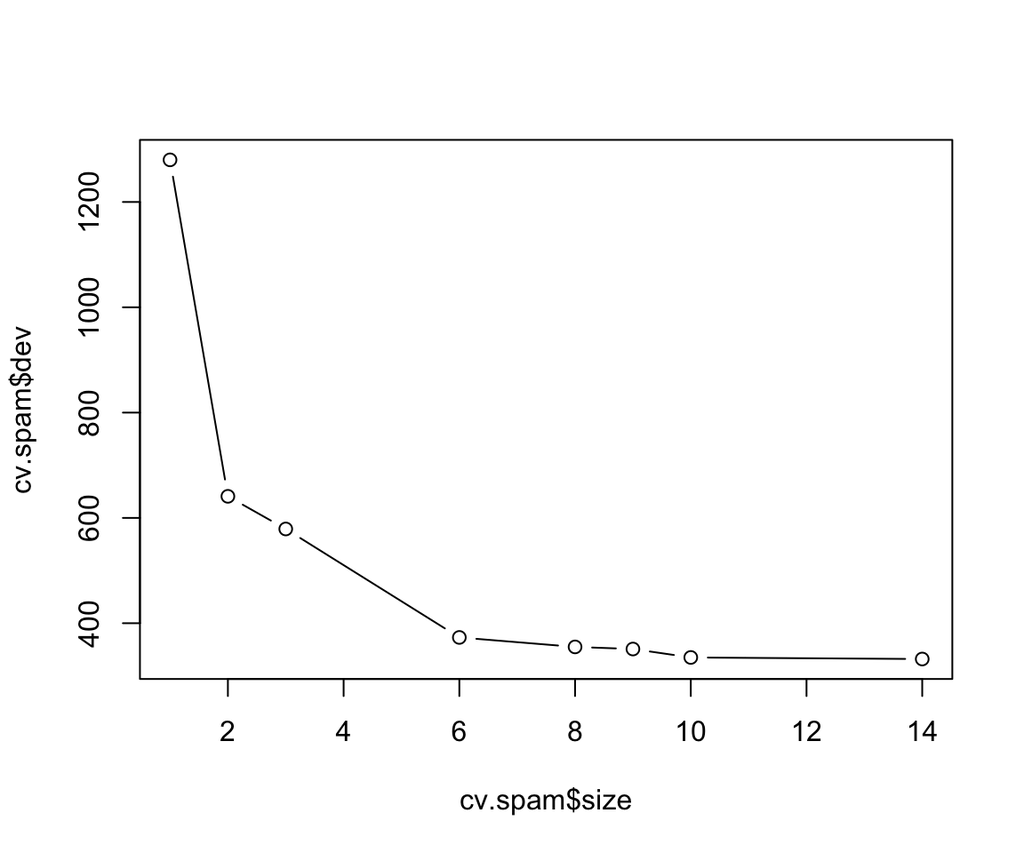

```r
set.seed(4268)

cv.spam <- cv.tree(spam.tree, FUN = prune.misclass)

plot(cv.spam$size, cv.spam$dev, type = "b")
```

According to the plot the optimal number of terminal nodes is 6 (or larger). We choose 6 as this gives the simplest tree, and prune the tree according to this value.

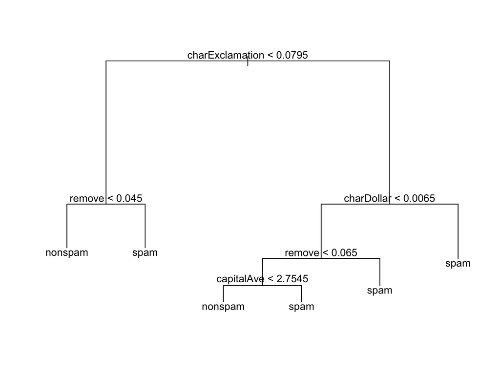

```r
prune.spam <- prune.misclass(spam.tree, best = 6)

plot(prune.spam)
text(prune.spam, pretty = 1)
```

We predict the response for the test data:

```r
yhat.prune <- predict(prune.spam, spam[test, ], type = "class")

misclass.prune <- table(yhat.prune, response.test)
misclass.prune
```

```
##           response.test
## yhat.prune nonspam spam
##    nonspam     796  104
##    spam         52  429
```

The misclassification rate is

```r
1 - sum(diag(misclass.prune)) / sum(misclass.prune)
```

```
## [1] 0.1129616
```

```r
library(randomForest)
bag.spam <- randomForest(type ~ .,
                         data = spam,
                         subset = train,
                         mtry = ncol(spam) - 1,
                         ntree = 500,
                         importance = TRUE)
```

We predict the response for the test data as before:

```r
yhat.bag <- predict(bag.spam, newdata = spam[test, ])

misclass.bag <- table(yhat.bag, response.test)
misclass.bag
```

```
##          response.test
## yhat.bag  nonspam spam
##   nonspam     810   43
##   spam         38  490
```

The misclassification rate is

```r
1 - sum(diag(misclass.bag)) / sum(misclass.bag)
```

```
## [1] 0.05865315
```

We now use the random forest-algorithm and consider only $\sqrt{57}\approx 8$ of the predictors at each split. This is specified in `mtry`.

```r
set.seed(4268)
rf.spam <- randomForest(type ~ .,
                        data = spam,
                        subset = train,
                        mtry = round(sqrt(ncol(spam) - 1)),
                        ntree = 500,
                        importance = TRUE)
```

We study the importance of each variable

```r
importance(rf.spam)
```

[output not shown]

If `MeanDecreaseAccuracy` and `MeanDecreaseGini` are large, the corresponding covariate is important.

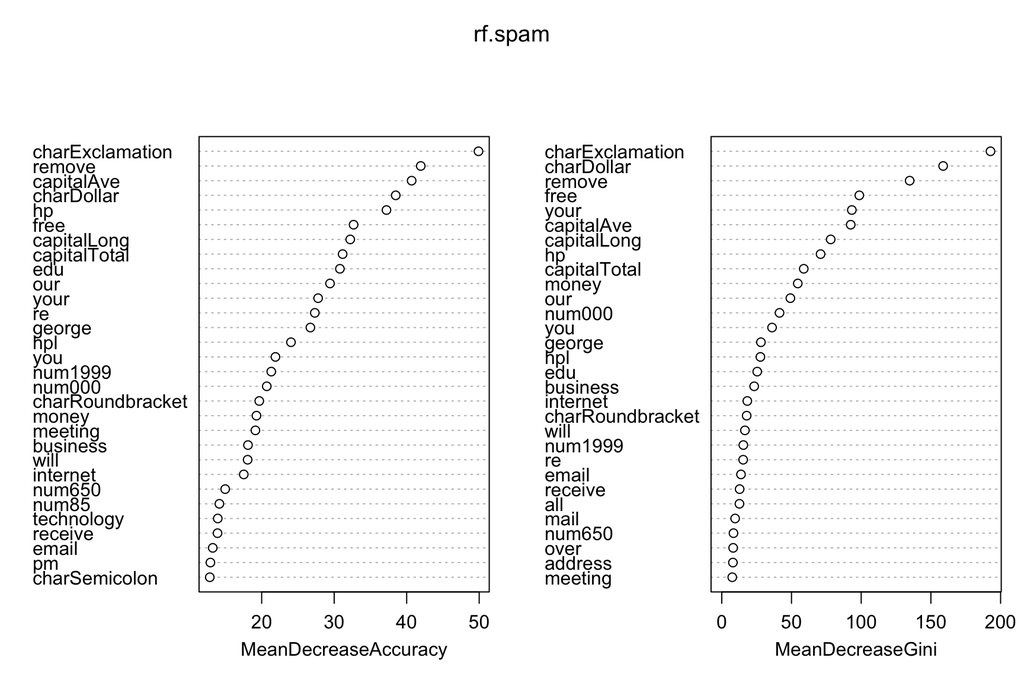

```r
varImpPlot(rf.spam)
```

In this plot we see that `charExclamation` is the most important covariate, followed by `remove` and `charDollar`. This is as expected as these variables are used in the top splits in the classification trees we have seen so far.

We now predict the response for the test data.

```r
yhat.rf <- predict(rf.spam, newdata = spam[test, ])

misclass.rf <- table(yhat.rf, response.test)
1 - sum(diag(misclass.rf)) / sum(misclass.rf)
```

```
## [1] 0.044895
```

The misclassification rate is given by

```r
misclass.rf
```

```
##          response.test
## yhat.rf   nonspam spam
##   nonspam     824   38
##   spam         24  495
```

8. The ranks of misclassification rates: 1) random forest, 2) bagging, 3) decision tree, with a higher rank indicating a lower misclassification rate. This order is what we expected.